# Graduate Assignment: Violent Crime and Property Crime in Maryland Counties Analysis

Daranee Balachandar

2023-11-26

#Violent Crime and Property Crime in Maryland Municipalities Analysis

For this data analysis project, I will be working with the Violent Crime & Property Crime by County: 1975 to Present Data (2020) https://opendata.maryland.gov/Public-Safety/Violent-Crime-Property-Crime-by-County-1975-to-Pre/jwfa-fdxs.

According to the Maryland State Open Data Portal web page, https://opendata.maryland.gov/Public-Safety/Violent-Crime-Property-Crime-by-County-1975-to-Pre/jwfa-fdxs the Violent Crime & Property Crime by County data is provided by the Maryland Statistical Analysis Center in the Governor’s Office of Crime Control and Prevention. The center receives the data from the Maryland State Police’s annual Uniform Crime Reports, a state program started in Maryland in 1975. The FBI assists the development of this program in order to make it compatible with the national version and the program involves uniform classification, compilation, review and analysis of crime statistics by all state law enforcement agencies.

The Maryland Department of State Police is responsible for the collection and dissemination of the UCR data in accordance to the Public Safety Article, Section 2, Subsection 307 and 308 in the Annotated Code of Maryland. The owner of the violent and property crime data set is the open data owner and its dissemination on the Open Data Portal is under Maryland’s Open Data Program. This data set was created on February 2, 2016 and was last updated on May 23, 2023.

As the time frame for the data set is between 1975 to 2020, I plan to explore the violent and property crime trends based on major events that have happened from 2010 to 2020. I’d also like to see if some crime trends reported in 2023 had started from 2016 to 2020.

## Data set up

Load libraries

Load Data

```r
#Load data
crime_data_1975_2020 <- read_csv("data/Violent_Crime___Property_Crime_by_County__1975_to_Present.csv")
#Data summary
summary(crime_data_1975_2020)
```

```
 JURISDICTION            YEAR        POPULATION          MURDER            RAPE
 Length:1104        Min.   :1975   Min.   :  16200   Min.   :  0.00   Min.   :  0.00
 Class :character   1st Qu.:1986   1st Qu.:  33049   1st Qu.:  1.00   1st Qu.:  9.00
 Mode  :character   Median :1998   Median :  90074   Median :  3.00   Median : 21.00
                    Mean   :1998   Mean   : 213571   Mean   : 19.79   Mean   : 67.26
                    3rd Qu.:2009   3rd Qu.: 237562   3rd Qu.:  7.00   3rd Qu.: 46.00
                    Max.   :2020   Max.   :1062595   Max.   :353.00   Max.   :754.00

    ROBBERY         AGG. ASSAULT         B & E         LARCENY THEFT       M/V THEFT
 Min.   :    0.0   Min.   :   11.0   Min.   :   32.0   Min.   :   91.0   Min.   :    2.0
 1st Qu.:   17.0   1st Qu.:  108.0   1st Qu.:  256.0   1st Qu.:  679.8   1st Qu.:   43.0
 Median :   48.0   Median :  257.5   Median :  609.5   Median : 1813.0   Median :  125.5
 Mean   :  584.4   Mean   :  836.5   Mean   : 1866.4   Mean   : 5559.2   Mean   : 1000.9
 3rd Qu.:  186.2   3rd Qu.:  545.5   3rd Qu.: 1230.0   3rd Qu.: 3766.2   3rd Qu.:  413.2
 Max.   :12408.0   Max.   :10536.0   Max.   :18604.0   Max.   :46750.0   Max.   :18482.0

  GRAND TOTAL    PERCENT CHANGE     VIOLENT CRIME TOTAL VIOLENT CRIME PERCENT
 Min.   :  152   Min.   :-29.5000   Min.   :   21.0     Min.   : 4.10
 1st Qu.: 1116   1st Qu.: -6.6000   1st Qu.:  140.0     1st Qu.: 9.50
 Median : 2840   Median : -0.5000   Median :  323.0     Median :12.60
 Mean   : 9934   Mean   : -0.4085   Mean   : 1507.9     Mean   :12.74
 3rd Qu.: 6042   3rd Qu.:  5.3000   3rd Qu.:  743.8     3rd Qu.:15.40
 Max.   :96243   Max.   : 62.9000   Max.   :22006.0     Max.   :33.70
                 NA's   :24
 VIOLENT CRIME PERCENT CHANGE PROPERTY CRIME TOTALS PROPERTY CRIME PERCENT
 Min.   :-78.60               Min.   :  126.0       Min.   :66.30
 1st Qu.: -8.90               1st Qu.:  963.8       1st Qu.:84.60
 Median :  0.35               Median : 2520.0       Median :87.40
 Mean   :  2.46               Mean   : 8426.5       Mean   :87.26
 3rd Qu.: 11.70               3rd Qu.: 5341.5       3rd Qu.:90.50
 Max.   :160.50               Max.   :74665.0       Max.   :95.90
 NA's   :24
 PROPERTY CRIME PERCENT CHANGE OVERALL CRIME RATE PER 100,000 PEOPLE
 Min.   :-31.7000              Min.   :  788.7
 1st Qu.: -6.7000              1st Qu.: 2437.7
 Median : -0.5000              Median : 3214.4
 Mean   : -0.5448              Mean   : 3688.5
 3rd Qu.:  5.5000              3rd Qu.: 4323.1
 Max.   : 75.0000              Max.   :13513.3
 NA's   :24
```

[output cut: 65 more lines]

```
 Min.   :-37.800
 1st Qu.: -7.700
 Median : -1.600
 Mean   : -1.182
 3rd Qu.:  4.825
 Max.   : 81.000
 NA's   :24
 M/V THEFT  RATE PERCENT CHANGE PER 100,000 PEOPLE
 Min.   :-74.300
 1st Qu.:-15.125
 Median : -1.500
 Mean   :  1.501
 3rd Qu.: 13.100
 Max.   :225.200
 NA's   :24
```

## Data Cleaning

```r
#Clean column names and change year column to a character column
crime_data_1975_2020 <- crime_data_1975_2020 |>
  clean_names() |>
  mutate(year = as.character(year))

#Rename jurisdiction column to county
crime_data_1975_2020 <- crime_data_1975_2020 |>
  rename(county = jurisdiction)
```

## Checking aggregates and data limitations in the data set

There are **1104 rows** and **38 columns** of data, which includes columns of data on the county in which the crimes took place, the year, the population of the county at that year and the types of crime cases such as rape, robbery, larceny theft, motor vehicle theft and more. There are also columns that calculate the grand total of crimes in the county in a certain year, percentage change of total crime for the year as compared to the previous year, the violent crime total, the percentage of violent crime, property crime totals, property crime percentage, violent crime percentage change, property crime percentage change, the overall crime rate per 100,000 people, the overall percent change per 100,000 people as well as the rate of different types of crimes per 100,000 people. Each row of the data is based on the yearly crime data in each county.

Firstly, the FBI classifies murder, rape, robbery and aggravated assault under violent crime https://ucr.fbi.gov/crime-in-the-u.s/2019/crime-in-the-u.s.-2019/topic-pages/violent-crime.pdf. Meanwhile, property crime includes offences such as burglary (breaking and entering, B&E), larceny-theft and motor vehicle theft. This data set does not include data on carjacking cases or arson cases. The reason being that the UCR did not record carjacking cases separately or distinctively until 2022 https://www.umpd.umd.edu/stats/ucr/legacy_ucr.cfm. Meanwhile, the FBI clarified that there is only limited data available for arson.

According to the title of the data set, it is meant to consist of data recorded from 1975 to present, which is 2020. This is kind of a limitation as the data is not current. However, this data project plans to explore how violent crime and property crime in Maryland is impacted by major national and state incidents.

Another limitation about this data set is the geographic scope of this data. This data is recorded based on crimes reported in in counties in Maryland and does not record data according to zip codes. The lack of zip codes may limit the exploration down to counties rather than the neighborhoods in which the crimes had taken place.

This data set comes with aggregate data columns such as grand total crimes, percent change of crimes from the year before, violent crime total, violent crime percentage, property crime total and property crime percentage. I will be checking this.

```r
#Calculate grand total of crimes
crime_data_1975_2020 |>
  group_by(county, year) |>
  summarise(crime_total=murder+rape+robbery+agg_assault+b_e+larceny_theft+m_v_theft)
```

| county | year | crime_total |
| --- | --- | --- |
| Allegany County | 1975 | 2329 |
| Allegany County | 1976 | 2125 |
| Allegany County | 1977 | 2211 |
| Allegany County | 1978 | 2131 |
| Allegany County | 1979 | 2322 |
| Allegany County | 1980 | 2474 |
| Allegany County | 1981 | 2473 |
| Allegany County | 1982 | 2189 |
| Allegany County | 1983 | 1948 |
| Allegany County | 1984 | 1857 |

[output cut: 990 more lines]

```r
#Calculate total of violent crimes by year
crime_data_1975_2020 |>
  group_by(county, year) |>
  mutate(
   violent_total = murder+rape+robbery+agg_assault) |>
   select(county, year, violent_crime_total, violent_total)
```

| county | year | violent_crime_total | violent_total |
| --- | --- | --- | --- |
| Allegany County | 1975 | 142 | 142 |
| Allegany County | 1976 | 87 | 87 |
| Allegany County | 1977 | 127 | 127 |
| Allegany County | 1978 | 102 | 102 |
| Allegany County | 1979 | 110 | 110 |
| Allegany County | 1980 | 119 | 119 |
| Allegany County | 1981 | 149 | 149 |
| Allegany County | 1982 | 117 | 117 |
| Allegany County | 1983 | 122 | 122 |
| Allegany County | 1984 | 90 | 90 |

[output cut: 990 more lines]

```r
#Calculate total of property crimes by year
crime_data_1975_2020 |>
  group_by(county, year) |>
  mutate(
    property_total = b_e+larceny_theft+m_v_theft) |>
    select(county, year, property_crime_totals, property_total)
```

| county | year | property_crime_totals | property_total |
| --- | --- | --- | --- |
| Allegany County | 1975 | 2187 | 2187 |
| Allegany County | 1976 | 2038 | 2038 |
| Allegany County | 1977 | 2084 | 2084 |
| Allegany County | 1978 | 2029 | 2029 |
| Allegany County | 1979 | 2212 | 2212 |
| Allegany County | 1980 | 2355 | 2355 |
| Allegany County | 1981 | 2324 | 2324 |
| Allegany County | 1982 | 2072 | 2072 |
| Allegany County | 1983 | 1826 | 1826 |
| Allegany County | 1984 | 1767 | 1767 |

[output cut: 990 more lines]

```r
#Calculate violent crime percent per county and per year
crime_data_1975_2020 |>
  group_by(county, year) |>
  mutate(
    violent_percent = (violent_crime_total/grand_total)*100) |>
    select(county, year, violent_crime_percent, violent_percent)
```

| county | year | violent_crime_percent | violent_percent |
| --- | --- | --- | --- |
| Allegany County | 1975 | 6.1 | 6.097037 |
| Allegany County | 1976 | 4.1 | 4.094118 |
| Allegany County | 1977 | 5.7 | 5.744007 |
| Allegany County | 1978 | 4.8 | 4.786485 |
| Allegany County | 1979 | 4.7 | 4.737295 |
| Allegany County | 1980 | 4.8 | 4.810024 |
| Allegany County | 1981 | 6.0 | 6.025071 |
| Allegany County | 1982 | 5.3 | 5.344906 |
| Allegany County | 1983 | 6.3 | 6.262834 |
| Allegany County | 1984 | 4.8 | 4.846527 |

[output cut: 990 more lines]

```r
#Calculate property crime percent per county and per year
crime_data_1975_2020 |>
  group_by(county, year) |>
  mutate(
    property_percent = (property_crime_totals/grand_total)*100) |>
  select(county, year, property_crime_percent, property_percent)
```

| county | year | property_crime_percent | property_percent |
| --- | --- | --- | --- |
| Allegany County | 1975 | 93.9 | 93.90296 |
| Allegany County | 1976 | 95.9 | 95.90588 |
| Allegany County | 1977 | 94.3 | 94.25599 |
| Allegany County | 1978 | 95.2 | 95.21351 |
| Allegany County | 1979 | 95.3 | 95.26270 |
| Allegany County | 1980 | 95.2 | 95.18998 |
| Allegany County | 1981 | 94.0 | 93.97493 |
| Allegany County | 1982 | 94.7 | 94.65509 |
| Allegany County | 1983 | 93.7 | 93.73717 |
| Allegany County | 1984 | 95.2 | 95.15347 |

[output cut: 990 more lines]

In order to calculate the per capita data per year, I will be using the population data provided in the dataset.

Something to note here is that the population data for each county in the data set is slightly different from what is pulled from ACS for that year. Some counties have population that is around 1,000 more or less in the dataset compared to what is found in the ACS for each county for each year.

With that in mind I will be using the population data in the data set to check the crime rate.

```r
#Calculate violent crime per capita per year and county
crime_data_1975_2020 |>
  group_by(county,year) |>
  mutate(
    violent_crime_rate = (violent_crime_total/population)*100000
  ) |>
  select(county, year, population, violent_crime_rate_per_100_000_people, violent_crime_rate)
```

| county | year | population | violent_crime_rate_per_100_000_people | violent_crime_rate |
| --- | --- | --- | --- | --- |
| Allegany County | 1975 | 79655 | 178.3 | 178.26878 |
| Allegany County | 1976 | 83923 | 103.7 | 103.66646 |
| Allegany County | 1977 | 82102 | 154.7 | 154.68563 |
| Allegany County | 1978 | 79966 | 127.6 | 127.55421 |
| Allegany County | 1979 | 79721 | 138.0 | 137.98121 |
| Allegany County | 1980 | 80461 | 147.9 | 147.89774 |
| Allegany County | 1981 | 81781 | 182.2 | 182.19391 |
| Allegany County | 1982 | 81858 | 142.9 | 142.93044 |
| Allegany County | 1983 | 82605 | 147.7 | 147.69082 |
| Allegany County | 1984 | 80835 | 111.3 | 111.33791 |

[output cut: 990 more lines]

```r
#Calculate property crime per capita per year and county
crime_data_1975_2020 |>
  group_by(county,year) |>
  mutate(
    property_crime_rate = (property_crime_totals/population)*100000
  ) |>
  select(county, year, population, property_crime_rate_per_100_000_people, property_crime_rate)
```

| county | year | population | property_crime_rate_per_100_000_people | property_crime_rate |
| --- | --- | --- | --- | --- |
| Allegany County | 1975 | 79655 | 2745.6 | 2745.5904 |
| Allegany County | 1976 | 83923 | 2428.4 | 2428.4165 |
| Allegany County | 1977 | 82102 | 2538.3 | 2538.3060 |
| Allegany County | 1978 | 79966 | 2537.3 | 2537.3284 |
| Allegany County | 1979 | 79721 | 2774.7 | 2774.6767 |
| Allegany County | 1980 | 80461 | 2926.9 | 2926.8838 |
| Allegany County | 1981 | 81781 | 2841.7 | 2841.7359 |
| Allegany County | 1982 | 81858 | 2531.2 | 2531.2126 |
| Allegany County | 1983 | 82605 | 2210.5 | 2210.5199 |
| Allegany County | 1984 | 80835 | 2185.9 | 2185.9343 |

[output cut: 990 more lines]

## Data Exploration

**Task 1** For this section, I will be exploring the overall crime rate in each county for the year 2020 using the ACS 2020 data. 2020 was the year the COVID-19 pandemic started and most of the state would have had to shut down in some parts of the year. It was also the year when the Black Lives Matter and George Floyd protests took place. With these two significant national and global events in mind, it would be interesting to see how it related to the overall crime in each county in Maryland that year.

```r
#Load ACS5 variables
acs5 <- load_variables(2020, "acs5", cache = TRUE)

acs5
```

| name | label | concept | geography |
| --- | --- | --- | --- |
| B01001A_001 | Estimate!!Total: | SEX BY AGE (WHITE ALONE) | tract |
| B01001A_002 | Estimate!!Total:!!Male: | SEX BY AGE (WHITE ALONE) | tract |
| B01001A_003 | Estimate!!Total:!!Male:!!Under 5 years | SEX BY AGE (WHITE ALONE) | tract |
| B01001A_004 | Estimate!!Total:!!Male:!!5 to 9 years | SEX BY AGE (WHITE ALONE) | tract |
| B01001A_005 | Estimate!!Total:!!Male:!!10 to 14 years | SEX BY AGE (WHITE ALONE) | tract |
| B01001A_006 | Estimate!!Total:!!Male:!!15 to 17 years | SEX BY AGE (WHITE ALONE) | tract |
| B01001A_007 | Estimate!!Total:!!Male:!!18 and 19 years | SEX BY AGE (WHITE ALONE) | tract |
| B01001A_008 | Estimate!!Total:!!Male:!!20 to 24 years | SEX BY AGE (WHITE ALONE) | tract |
| B01001A_009 | Estimate!!Total:!!Male:!!25 to 29 years | SEX BY AGE (WHITE ALONE) | tract |
| B01001A_010 | Estimate!!Total:!!Male:!!30 to 34 years | SEX BY AGE (WHITE ALONE) | tract |

[output cut: 990 more lines]

```r
md_county_population <- get_acs(geography = "county",
              variables = c(population = "B01001_001"),
              year = 2020,
              state = "MD",
              geometry = TRUE)
```

```
Downloading feature geometry from the Census website.  To cache shapefiles for use in future sessions, set `options(tigris_use_cache = TRUE)`.
```

```r
md_county_population
```

```
Simple feature collection with 24 features and 5 fields
Geometry type: MULTIPOLYGON
Dimension:     XY
Bounding box:  xmin: -79.48765 ymin: 37.91172 xmax: -75.04894 ymax: 39.72304
Geodetic CRS:  NAD83
First 10 features:
   GEOID                             NAME   variable estimate moe                       geometry
1  24041          Talbot County, Maryland population    37087  NA MULTIPOLYGON (((-76.34647 3...
2  24033 Prince George's County, Maryland population   910551  NA MULTIPOLYGON (((-77.07995 3...
3  24035    Queen Anne's County, Maryland population    50163  NA MULTIPOLYGON (((-76.24918 3...
4  24023         Garrett County, Maryland population    29155  NA MULTIPOLYGON (((-79.48765 3...
5  24039        Somerset County, Maryland population    25699  NA MULTIPOLYGON (((-75.95962 3...
6  24037      St. Mary's County, Maryland population   113182  NA MULTIPOLYGON (((-76.74729 3...
7  24001        Allegany County, Maryland population    71002  NA MULTIPOLYGON (((-79.06675 3...
8  24003    Anne Arundel County, Maryland population   575421  NA MULTIPOLYGON (((-76.83849 3...
9  24029            Kent County, Maryland population    19456  NA MULTIPOLYGON (((-76.27737 3...
10 24013         Carroll County, Maryland population   168233  NA MULTIPOLYGON (((-77.31129 3...
```

```r
#Filter the crime rate for each county in 2020
county_crime_rate_2020 <- crime_data_1975_2020 |>
  filter(year == 2020)
```

```r
#Prep MD county population dataset for joining
md_county_population <- md_county_population |>
  rename(county = NAME) |>
  mutate(county = str_to_title(str_remove_all(county,", Maryland"))) |>
  mutate(county = str_trim(county,side="both")) |>
  rename(population = estimate) |>
  select(county, population, geometry)
```

```r
#Join MD county population with county crime rate 2020
md_county_crime_rate <- md_county_population |>
  left_join(county_crime_rate_2020, join_by(county))
```

```r
counties <- counties()
glimpse(counties)
```

```
Rows: 3,234
Columns: 18
$ STATEFP  <chr> "31", "53", "35", "31", "31", "72", "46", "48", "06", "21", "39", "48", "01", …
$ COUNTYFP <chr> "039", "069", "011", "109", "129", "085", "099", "327", "091", "053", "063", "…
$ COUNTYNS <chr> "00835841", "01513275", "00933054", "00835876", "00835886", "01804523", "01265…
$ GEOID    <chr> "31039", "53069", "35011", "31109", "31129", "72085", "46099", "48327", "06091…
$ NAME     <chr> "Cuming", "Wahkiakum", "De Baca", "Lancaster", "Nuckolls", "Las Piedras", "Min…
$ NAMELSAD <chr> "Cuming County", "Wahkiakum County", "De Baca County", "Lancaster County", "Nu…
$ LSAD     <chr> "06", "06", "06", "06", "06", "13", "06", "06", "06", "06", "06", "06", "06", …
$ CLASSFP  <chr> "H1", "H1", "H1", "H1", "H1", "H1", "H1", "H1", "H1", "H1", "H1", "H1", "H1", …
$ MTFCC    <chr> "G4020", "G4020", "G4020", "G4020", "G4020", "G4020", "G4020", "G4020", "G4020…
$ CSAFP    <chr> NA, NA, NA, "339", NA, "490", NA, NA, NA, NA, "534", "352", NA, "108", "338", …
$ CBSAFP   <chr> NA, NA, NA, "30700", NA, "41980", "43620", NA, NA, NA, "22300", "38380", NA, "…
$ METDIVFP <chr> NA, NA, NA, NA, NA, NA, NA, NA, NA, NA, NA, NA, NA, NA, NA, NA, NA, NA, NA, NA…
$ FUNCSTAT <chr> "A", "A", "A", "A", "A", "A", "A", "A", "A", "A", "A", "A", "A", "A", "A", "A"…
$ ALAND    <dbl> 1477645345, 680976231, 6016818946, 2169272970, 1489645185, 87748418, 208970144…
$ AWATER   <dbl> 10690204, 61568965, 29090018, 22847034, 1718484, 32509, 18188795, 613559, 2329…
$ INTPTLAT <chr> "+41.9158651", "+46.2946377", "+34.3592729", "+40.7835474", "+40.1764918", "+1…
$ INTPTLON <chr> "-096.7885168", "-123.4244583", "-104.3686961", "-096.6886584", "-098.0468422"…
$ geometry <MULTIPOLYGON [°]> MULTIPOLYGON (((-96.55515 4..., MULTIPOLYGON (((-123.4908 4..., M…
```

```r
md_counties <- counties |>
  filter(STATEFP == "24")
```

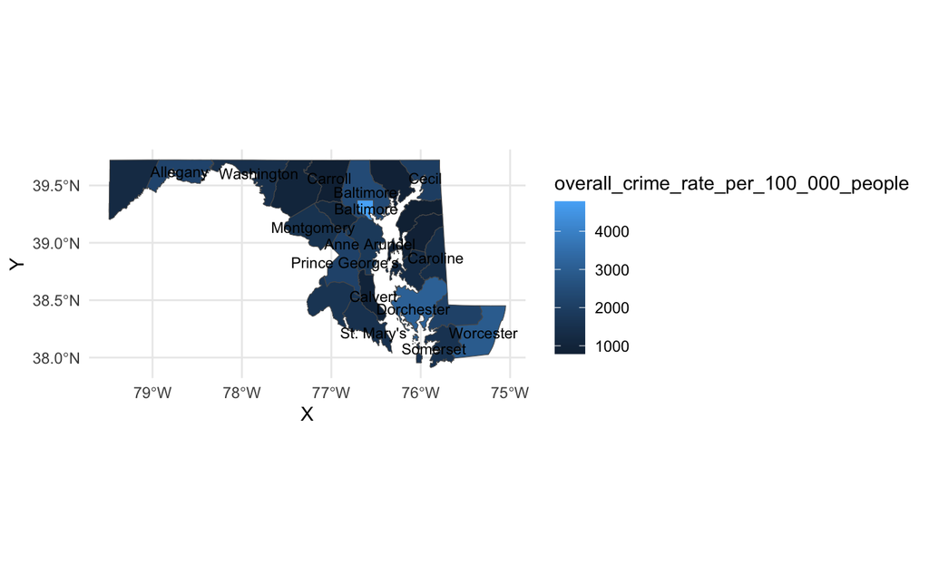

```r
#Plot a map of the crime rate in 2020
county_centroids <- st_centroid(md_counties)
county_centroids_df <- as.data.frame(st_coordinates(county_centroids))
county_centroids_df$NAME <- county_centroids$NAME

ggplot() +
  geom_sf(data=md_county_crime_rate, aes(fill=overall_crime_rate_per_100_000_people)) +
  geom_text(aes(x = X, y = Y, label = NAME), data = county_centroids_df, size = 3, check_overlap = TRUE) +
  theme_minimal()
```

**Task note** By calculating the overall crime rates per 100,000 people in each county for 2020, it shows that the last year with recorded data for this data set showed that Baltimore City has the highest overall crime rate for 2020. The other counties with high crimes rate per 100,000 people is Dorchester County and Worcester County. Baltimore City population is predominantly African American at 61.6%, according to the US Census for the city, whereas Dorchester County and Worcester County are predominantly white 66.4% and 83.3% respectively. It is expected that Baltimore City would have a high crime rate, even during the pandemic and also keeping in mind the Black Lives Matter and George Floyd protests. However, the crime rates for Dorchester County and Worcester County in 2020 is interesting as they are also located in more rural areas.

**Task 2** Now, with that in mind, I’d like to place the above information in context and see the counties with the highest total crime from 1975 to 2020.

```r
#Calculate total of each type of crime for each county from 1975 to 2020
county_total_crimes <- crime_data_1975_2020 |>
  group_by(county) |>
  summarise(
    total_murder = sum(murder),
    total_rape = sum(rape),
    total_robbery = sum(robbery),
    total_agg_assault = sum(agg_assault),
    total_b_e = sum(b_e),
    total_larceny_theft = sum(larceny_theft),
    total_m_v_theft = sum(m_v_theft)
  )
```

```r
#Create total of violent crimes
county_total_crimes <- county_total_crimes |>
   group_by(county) |>
   mutate(
     total_violent_crimes = total_murder+total_rape+total_robbery+total_agg_assault
   )

#Create total of property crimes
county_total_crimes <- county_total_crimes |>
   group_by(county) |>
   mutate(
     total_property_crimes = total_b_e+total_larceny_theft+total_m_v_theft
   )

#Create total crimes
county_total_crimes <- county_total_crimes |>
   group_by(county) |>
   mutate(
     total_crimes = total_b_e+total_larceny_theft+total_m_v_theft+total_murder+total_rape+total_robbery+total_agg_assault
   )
```

Write out the csv of the total crimes from 1975 to 2020 by county.

```r
#Write out csv for county_total_crimes
write.csv(county_total_crimes, "county_total_crimes.csv", row.names = TRUE)
```

Here is the link for the map: https://www.datawrapper.de/_/9MwH0/

```r
#Create a dataset for Baltimore Crime from 2016 to 2020
baltimore_crime_rate_2016_2020 <- crime_data_1975_2020 |>
  filter(year >= 2016 , year <= 2020) |>
  filter(str_detect(county, "Baltimore City")) |>
  select(county, year, violent_crime_rate_per_100_000_people, property_crime_rate_per_100_000_people,   overall_crime_rate_per_100_000_people)
```

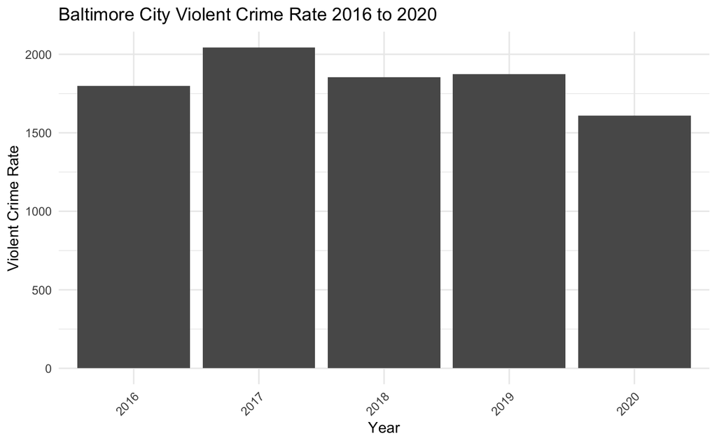

```r
#Create a bar graph for Baltimore City Violent Crime Rate
baltimore_crime_rate_2016_2020 |>
   ggplot() +
  geom_bar(
    aes(
      x = year,
      weight = violent_crime_rate_per_100_000_people)) +
  labs(
    x = "Year",
    y = "Violent Crime Rate",
    title = "Baltimore City Violent Crime Rate 2016 to 2020") +
  theme_minimal () +
  theme(axis.text.x = element_text(angle = 45, hjust = 1))
```

Then, the property crime rate in Baltimore City from 2016 to 2020.

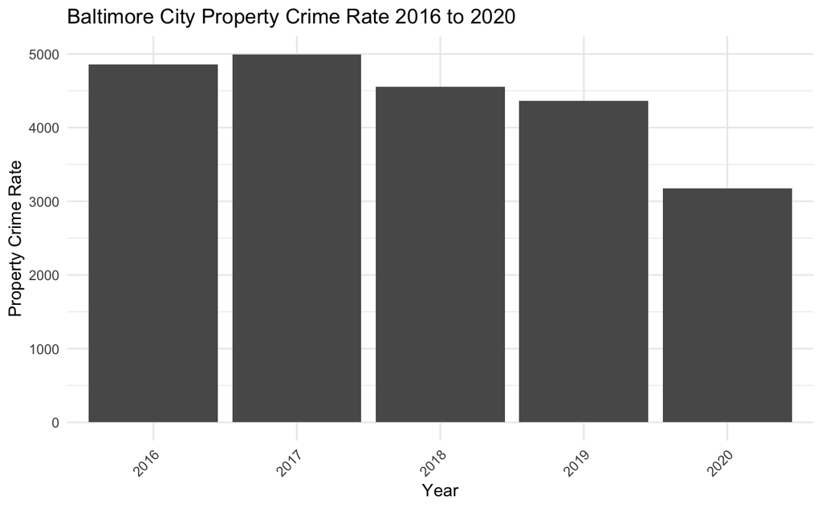

```r
#Create a bar graph for Baltimore City Property Crime Rate
baltimore_crime_rate_2016_2020 |>
   ggplot() +
  geom_bar(
    aes(
      x = year,
      weight = property_crime_rate_per_100_000_people)) +
  labs(
    x = "Year",
    y = "Property Crime Rate",
    title = "Baltimore City Property Crime Rate 2016 to 2020") +
  theme_minimal () +
  theme(axis.text.x = element_text(angle = 45, hjust = 1))
```

**Task notes** These bar graphs show that property and violent crime rates have decreased in 2020. Chronologically, we can see that property crime rates were dropping from 2017 to 2019 and made a bigger drop in 2020 due to the pandemic. Although there was a drop in violent crime rate in 2020, it wasn’t a huge drop and it seemed like violent crime rates from 2016 to 2019 were around 1,800 cases per 100,000 people, with 2017 peaking at around 2,000 cases per 100,000 people.

**Task 4** The next step is to identify the top three types of crimes (violent and/or property crimes) that are most prevalent statewide in 2018, 2019 and 2020.

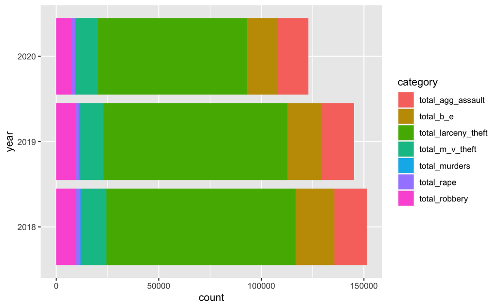

```r
#Calculate the total crimes statewide by year
statewide_crime_totals <- crime_data_1975_2020 |>
  group_by(year) |>
  summarize(total_murders = sum(murder), total_rape = sum(rape), total_robbery = sum(robbery),   total_agg_assault = sum(agg_assault), total_b_e = sum(b_e), total_larceny_theft = sum(larceny_theft), total_m_v_theft = sum(m_v_theft)) |>
  filter(year >= 2018) |>
  pivot_longer(cols=-year, names_to='category', values_to = 'crimes')

#Create a bar graph of total crimes statewide from 2018 to 2020
statewide_crime_totals |>
  ggplot() +
  geom_bar(aes(x=year, weight=crimes, fill=category)) +
  coord_flip()
```

**Task note** This bar graph shows a breakdown of all types of violent and property crimes and their trends from 2018 to 2020 in Maryland. From this bar graph, we notice that the crime with the highest totals in those years is larceny theft, followed by breaking and entering, aggravated assault and motor vehicle theft.

Based on this graph, the total crime had decreased from 2018 to 2019 to 2020, with total crimes in 2020 being the lowest. It shows that robbery, larceny theft, and motor vehicle thefts and breaking and entering are crimes that decreased from 2018 to 2020, which are largely property crime.

Note: This bar graph was created with the help of Derek and ChatGPT. I was unsure how to create a graph using three variables instead of two.

##Question 1 Was there a statewide surge or decline in violent and property crime in 2020 as compared to 2019 and 2018?

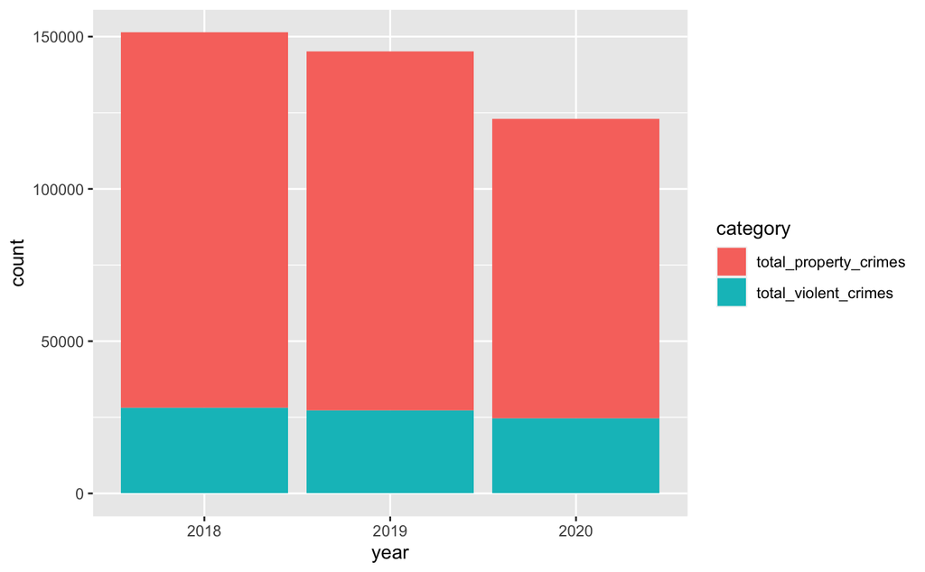

```r
#Calculate top three crimes statewide in 2018
crime_2018_2019_2020 <- crime_data_1975_2020|>
  group_by(year) |>
  summarize(total_violent_crimes = sum(violent_crime_total), total_property_crimes =     sum(property_crime_totals)) |>
  filter(year >= 2018) |>
  pivot_longer(cols=-year, names_to='category', values_to = 'crimes')

#Create a bar graph
crime_2018_2019_2020|>
  ggplot() +
  geom_bar(aes(x=year, weight=crimes, fill=category))
```

**Answer** Based on this bar graph, we see that property crimes did drop by around 25,000 cases in 2020 compared to 2018. It also shows that property crimes have been decreasing from 2018 to 2019 and then 2020. So it may show that the first year of the COVID-19 pandemic did make a difference in property crimes but a small one. It would be interesting to compare this trend with the 2021 to 2023 data as that is the time period in which the country and states were trying to recover economically and socially after COVID-19 became an endemic.

One point in this bar chart shows that there isn’t much difference or decline in 2020 total violent crimes statewide as compared to 2018 and 2019. Based on the previous bar chart in task 4 that shows a breakdown of violent crimes data that did not seem to change much from 2018 to 2020. The bar chart in task 4 showed that total robberies did go down slightly in 2020 but aggravated assault, murder and rape seemed to be similar to past years. Since people were mainly indoors in 2020, not seeing a spike in these crimes and this may tie with domestic violence crimes may be a good thing.

##Question 2 By looking at how violent crime does not change, what is the trend in rape statewide from 1975 to 2020? Is this one crime that has not seen much change overall in the last 45 years?

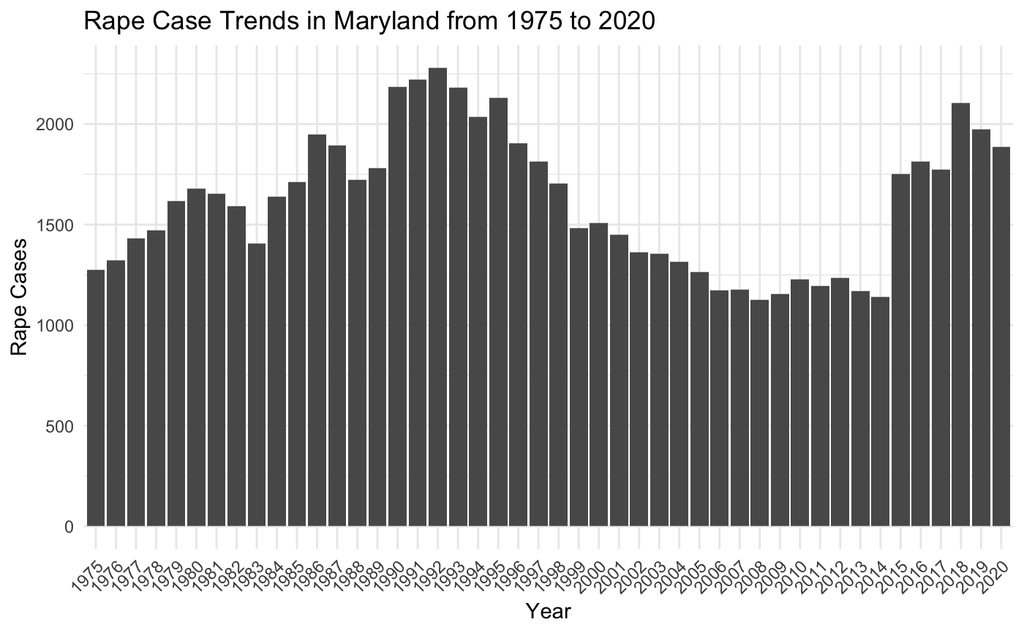

```r
rape_data_1975_2020 <- crime_data_1975_2020 |>
  group_by(year) |>
  summarize(total_rape = sum(rape)) |>
  pivot_longer(cols=-year, names_to='category', values_to = 'crimes') |>
  select(year, crimes)

rape_data_1975_2020 |>
  ggplot() +
  geom_bar(
    aes(
      x = year,
      weight = crimes)) +
  labs(
    x = "Year",
    y = "Rape Cases",
    title = "Rape Case Trends in Maryland from 1975 to 2020") +
  theme_minimal () +
  theme(axis.text.x = element_text(angle = 45, hjust = 1))
```

**Answer** This graph shows that a reported rape cases had increased between 1975 to 1995. However, a gradual decrease in rape cases is seen from 1995 to 2014 and then an uptick in 2015 and then another slightly smaller surge between 2017 and 2018. 2018 was the year of the Me Too movement and the surge in rape cases reported may be attributed to that. It would be interesting to look more into the surge between 2014 to 2015.

##Question 3 Motor vehicle thefts have been prevalent in Maryland, based on reports in the last 5 years. Is this trend new in the 2020s or was there any indication of the trend rising from 2016 to 2020?

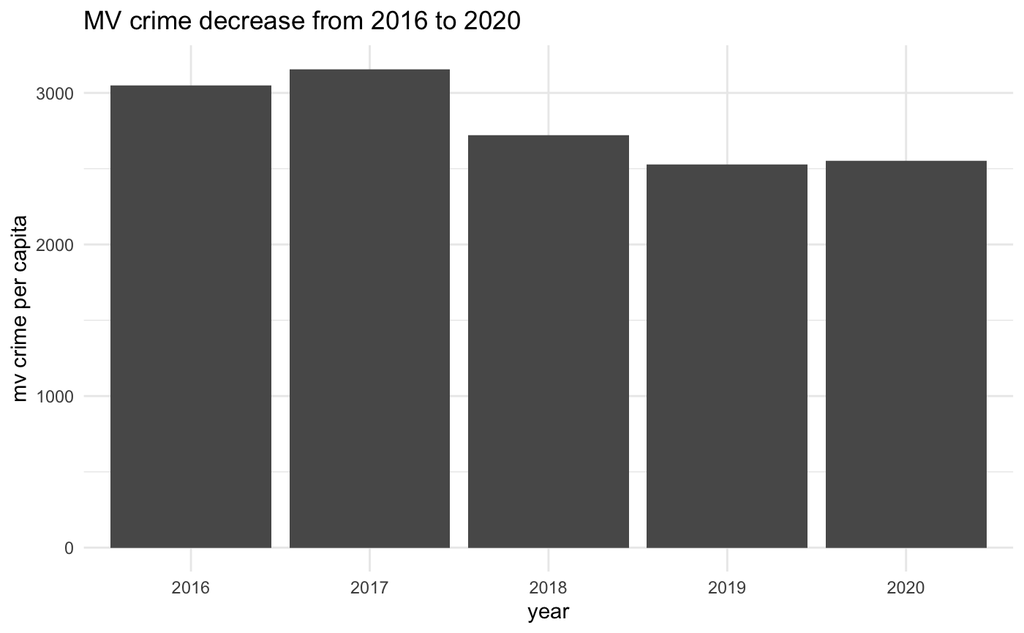

```r
#Create a dataframe of MV crime from 2016 to 2020
mv_crime_2016_2020 <- crime_data_1975_2020 |>
  group_by(year) |>
  summarize(total_m_v_crimes = sum(m_v_theft), total_m_v_crime_per_capita = sum(m_v_theft_per_100_000_people)) |>
  filter(year >= 2016)

#Plot a line graph
mv_crime_2016_2020 |>
  select(year, total_m_v_crime_per_capita) |>
ggplot() +
  geom_bar(aes(x=year, weight=total_m_v_crime_per_capita)) +
  theme_minimal() +
  labs(
    title="MV crime decrease from 2016 to 2020",
    x = "year",
    y = "mv crime per capita"
  )
```

**Answer** This bar graph shows that motor vehicle crime per capita has decreased from 2016 to 2020. In order to follow up with this, it would be good to compare this with the motor vehicle crime per capita from 2021 to 2023. If there is a large surge between 2021 to 2023, it would be interesting to find out the reason for the surge.

##Question 4 In 2023, there were reports that motor vehicle thefts and carjackings were mostly committed by juveniles. With age being a factor, what is the median age for each Maryland county and is there a relationship between the median age of counties and the total motor vehicle crime in the counties.

```r
#Create mv crime data for 2019
m_v_crime_2019 <- crime_data_1975_2020 |>
  group_by(county) |>
  filter(year == 2019) |>
  summarize(total_m_v_crimes = sum(m_v_theft), total_m_v_crime_per_capita = sum(m_v_theft_per_100_000_people))
```

```r
#Load ACS5 variables
acs5 <- load_variables(2019, "acs5", cache = TRUE)

acs5
```

| name | label | concept | geography |
| --- | --- | --- | --- |
| B01001A_001 | Estimate!!Total: | SEX BY AGE (WHITE ALONE) | tract |
| B01001A_002 | Estimate!!Total:!!Male: | SEX BY AGE (WHITE ALONE) | tract |
| B01001A_003 | Estimate!!Total:!!Male:!!Under 5 years | SEX BY AGE (WHITE ALONE) | tract |
| B01001A_004 | Estimate!!Total:!!Male:!!5 to 9 years | SEX BY AGE (WHITE ALONE) | tract |
| B01001A_005 | Estimate!!Total:!!Male:!!10 to 14 years | SEX BY AGE (WHITE ALONE) | tract |
| B01001A_006 | Estimate!!Total:!!Male:!!15 to 17 years | SEX BY AGE (WHITE ALONE) | tract |
| B01001A_007 | Estimate!!Total:!!Male:!!18 and 19 years | SEX BY AGE (WHITE ALONE) | tract |
| B01001A_008 | Estimate!!Total:!!Male:!!20 to 24 years | SEX BY AGE (WHITE ALONE) | tract |
| B01001A_009 | Estimate!!Total:!!Male:!!25 to 29 years | SEX BY AGE (WHITE ALONE) | tract |
| B01001A_010 | Estimate!!Total:!!Male:!!30 to 34 years | SEX BY AGE (WHITE ALONE) | tract |

[output cut: 990 more lines]

```r
#Get the median age per county using ACS
med_age <- get_acs(geography = "county",
              variables = c(medianage = "B01002_001"),
              state = "MD",
              year = 2019) |>
arrange(estimate)
```

```r
#Clean median age data
med_age <- med_age |>
  clean_names() |>
  select(name, estimate) |>
  rename(county = name) |>
   mutate(county = str_to_title(str_remove_all(county,", Maryland"))) |>
  mutate(county = str_trim(county,side="both")) |>
  rename(age = estimate)

#Join median age data with MV crime 2019
m_v_theft_median_age <- med_age |>
  left_join(m_v_crime_2019, join_by(county==county))

m_v_theft_median_age |>
  arrange(desc(age))
```

| county | age | total_m_v_crimes | total_m_v_crime_per_capita |
| --- | --- | --- | --- |
| Talbot County | 50.5 | 9 | 24.5 |
| Worcester County | 50.4 | 30 | 58.1 |
| Kent County | 48.1 | 5 | 26.1 |
| Garrett County | 46.2 | 5 | 17.3 |
| Dorchester County | 44.6 | 29 | 91.3 |
| Queen Anne's County | 44.4 | 28 | 55.7 |
| Carroll County | 42.4 | 72 | 42.9 |
| Allegany County | 41.7 | 61 | 87.0 |
| Harford County | 40.9 | 116 | 45.7 |
| Cecil County | 40.8 | 143 | 139.5 |

[output cut: 14 more lines]

```r
NA
```

**Answer** According to the data above, it does not seem like age is a factor in counties that have experienced a high mv theft rate. Instead we may attribute the high mv theft rate to them happening in urban areas such as Prince George’s County and Baltimore City. I would say that it is interesting that Montgomery county had a low mv crime rate per capita in 2019 since it is a highly populated county.

```r
#Create dataframe with violent crime in 2019
violent_crime_2019 <- crime_data_1975_2020 |>
  filter(year == 2019) |>
  select(county, population, violent_crime_percent) |>
  filter(violent_crime_percent >= 15)

# Get median income from ACS
med_income <- get_acs(geography="county", variables = c(medianincome = "B07411_001"), state='MD', year=2019)
```

```r
#Clean median income data
med_income <- med_income |>
  clean_names() |>
  select(name, estimate) |>
  rename(county = name)  |>
  mutate(county = str_to_title(str_remove_all(county,", Maryland"))) |>
  mutate(county = str_trim(county,side="both"))

#Join median income data with filtered violent crime data 2019
violent_crime_med_income <- med_income |>
  inner_join(violent_crime_2019, join_by (county==county))

#Select the columns in dataset
violent_crime_med_income |>
  select(county, estimate, violent_crime_percent) |>
  arrange(desc(estimate))
```

| county | estimate | violent_crime_percent |
| --- | --- | --- |
| Charles County | 47507 | 18.9 |
| Frederick County | 43520 | 16.7 |
| Harford County | 41731 | 16.2 |
| Baltimore County | 39159 | 18.8 |
| Baltimore City | 30200 | 30.1 |
| Washington County | 30128 | 17.9 |
| Garrett County | 28891 | 18.3 |
| Wicomico County | 27613 | 15.0 |
| Somerset County | 20894 | 17.6 |

```r
NA
```

##Question 6 Does mv theft increase affect car sales in counties?

```r
mv_crime_2016_2020 <- mv_crime_2016_2020
```

```r
#Load MVA vehicle sales data
vehicle_sales_2002_to_2023 <- read_csv("data/MVA_Vehicle_Sales_Counts_by_Month_for_Calendar_Year_2002_through_August_2023.csv")
```

```r
#Filter and clean vehicle sales data
vehicle_sales_2016_2020 <- vehicle_sales_2002_to_2023 |>
  clean_names() |>
  group_by(year) |>
  summarize(new_sales = sum(total_sales_new), used_sales = sum(total_sales_used)) |>
  filter (year >= 2016) |>
  mutate(total_sales = new_sales + used_sales) |>
  mutate(year = as.character(year))

#Join dataset
mv_theft_vehicle_sales <- vehicle_sales_2016_2020 |>
  inner_join(mv_crime_2016_2020, join_by (year==year))

#Select columns
mv_theft_vehicle_sales <- mv_theft_vehicle_sales |>
  select(year, total_sales, total_m_v_crimes)
```

```r
#Write out csv for mv_theft_vehicle_sales
write.csv(mv_theft_vehicle_sales, "mv_theft_vehicle_sales.csv", row.names = TRUE)
```

**Answer** Here is a Datawrapper bar chart showing the trend of MV theft crimes and vehicle sales from 2016 to 2020. https://www.datawrapper.de/_/lGUHF/

Based on the chart, it seems that car sales rose from 2016 to 2020 while motor vehicle thefts declined. This is interesting to see if the decline in mv thefts made people feel safer in buying cars.

## Memo

The first pitch is to look into the violent crime data in 2020 which includes rape, aggravated assault, murder and robbery which did not change much (except for robbery) as compared to previous years. This trend of no change is both reassuring that there was no icrease in such violent crimes in a difficult year plagued by the pandemic and protests. However, this dataset does not have any data on domestic violence. In order to look further into this, I plan to find data on domestic violence cases in from 2017 to 2021 as it would be a large set to track the trends in domestic violence and then to compare it with this dataset. I would like to also interview police officers in counties with the highest cases of violent crimes historically and see if this data matches up.

Next, I would like to look into the rape trend in Maryland from 1975 to 2020 and try to map out different events, or passing of legislations that may have affected such surge in 1975 to 1995, a decline from 1995 to 2014 and then to look further into what had happened in 2014 that led to a surge in 2015. I would also like to look closely into the data and see the demographics of the counties that had recorded the highest rate of rape. Reading this ProPublica article (sorry it’s a patch website)https://patch.com/maryland/baltimore/early-dna-evidence-decades-old-rape-cases-are-both-promising-alarming, I see that this is still a relevant topic with serial rapists still around and cases that were not reported previously still being reported.

Finally, I would like to take a look into the relationship between the decrease in motor vehicle crime statewide from 2016 to 2020 and see if that had affected the rise in car sales those years. For this story, I plan to get further data on motor vehicle theft and carjacking cases from 2021 to 2023 and compare that to the 2016 to 2020 dataset. The vehicle sales data only had the sales of used and new cars without a breakdown of the type of cars. During a public safety meeting at College Park with the PG County Police Department, the major had mentioned that Hyundais and Kias were the car types that would be either stolen or carjacked. Looking at this it would be good to get data on a further breakdown on the type of vehicles that were stolen and then to compare that to the new or used car sales for a certain county.

Overall, it is quite difficult to pinpoint a current news story using crime data especially according to county from 1975 to 2020. However, these trends listed above and explored in this project on violent crime cases in 2020 and rape case trends in 45 years are stories that are still relevant today. I hope to look into these stories further with more data exploration and interviewing sources on this.